# Gapminder_soln

David Sasson

3/6/2019

```r
knitr::opts_chunk$set(echo = TRUE, warning = FALSE, out.width = '70%', fig.align = "center")
library(tidyverse)
library(dslabs)
library(gapminder)
```

# Solutions

### Part I

1. How would you plot the relationship between `cty`, the average city mileage, and `hwy`, the averabe highway mileage? How would you describe this relationship?

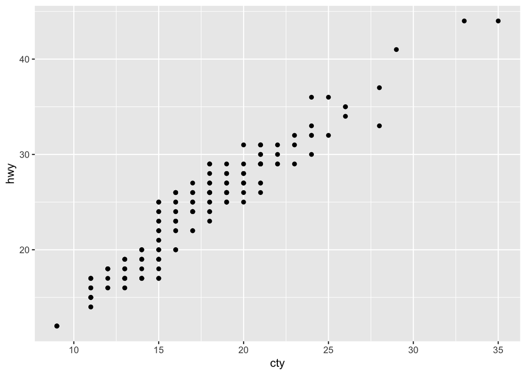

```r
ggplot(mpg, aes(cty, hwy)) +
  geom_point()
```

The point here to make is that this very linear relationship is of course caused by another factor, motor size. That is to say, the description “the higher/lower cty, the higher/lower hwy” is to taken as strictly descriptive.

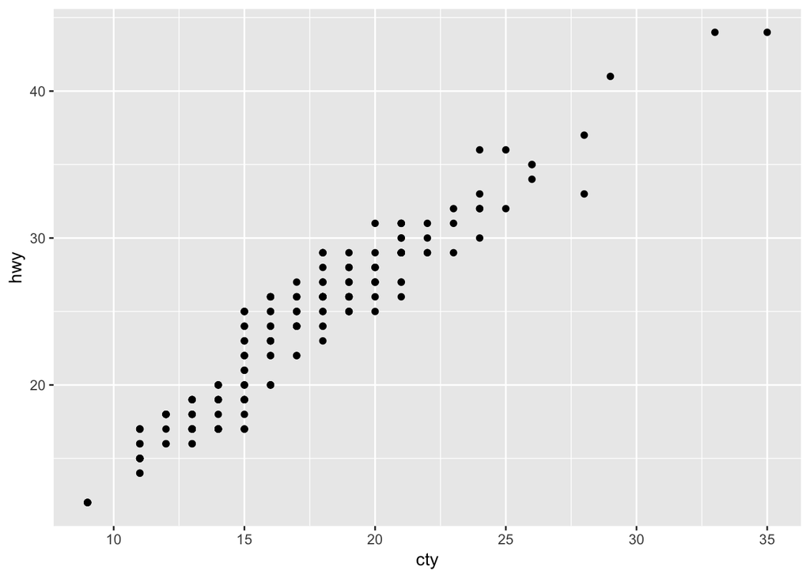

```r
ggplot(mpg, aes(cty, hwy)) + geom_point()
```

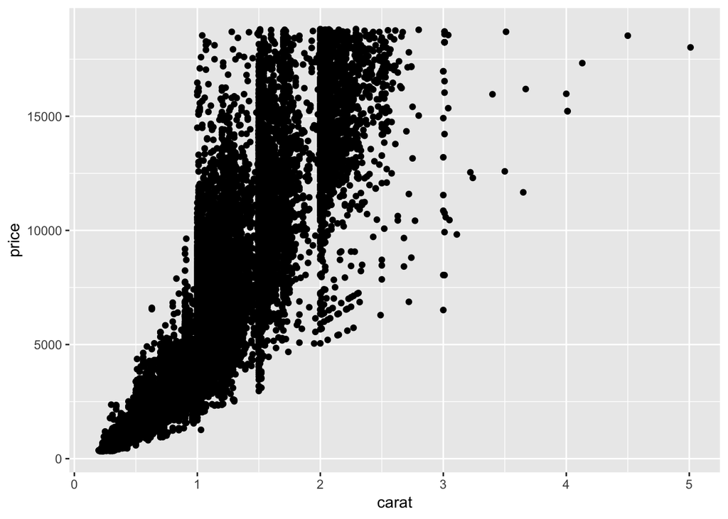

```r
ggplot(diamonds, aes(carat, price)) + geom_point()
```

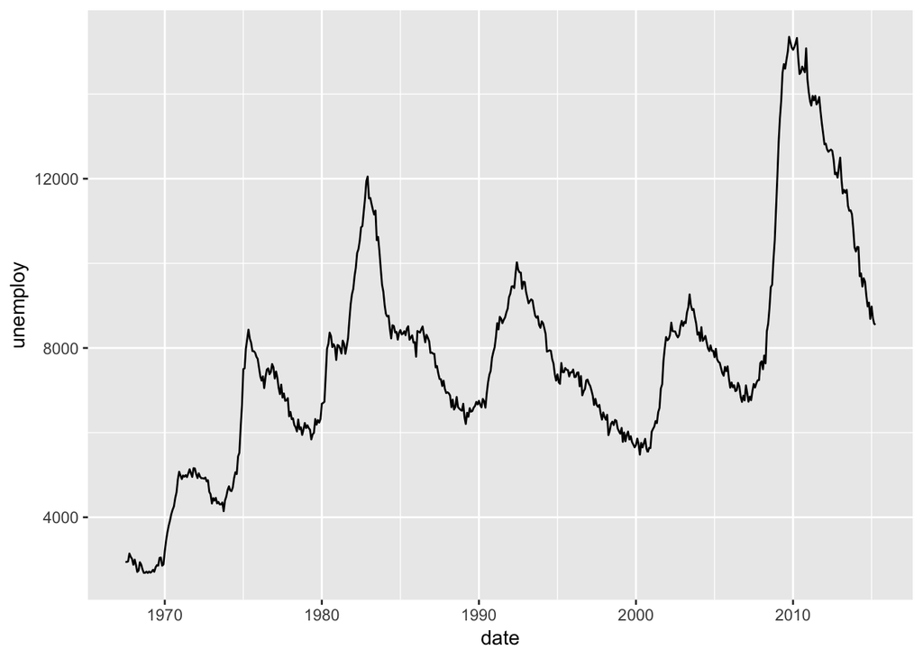

```r
ggplot(economics, aes(date, unemploy)) + geom_line()
```

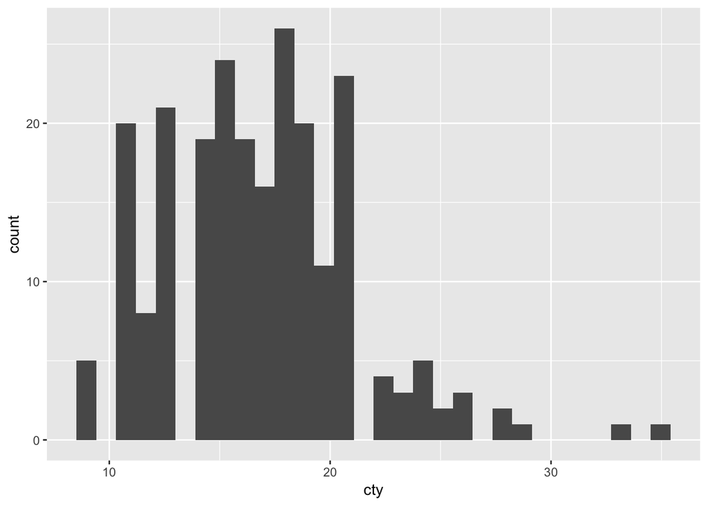

```r
ggplot(mpg, aes(cty)) + geom_histogram()
```

3. What happens if you make a scatter plot of class vs drv? Why is the plot not useful? What geometry object could you change to make it more meaningful?

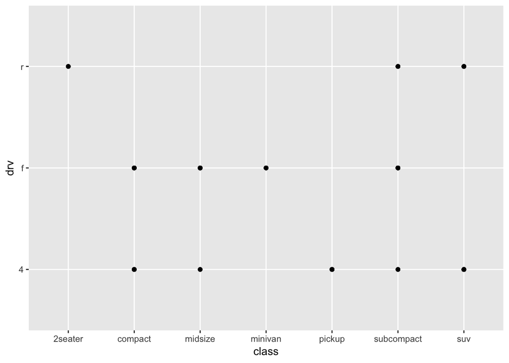

```r
ggplot(mpg, aes(x = class, y = drv)) +
  geom_point()
```

A scatter plot is not a useful display of these variables since both drv and class are categorical variables. Since categorical variables typically take a small number of values, there are a limited number of unique combinations of (x, y) values that can be displayed.

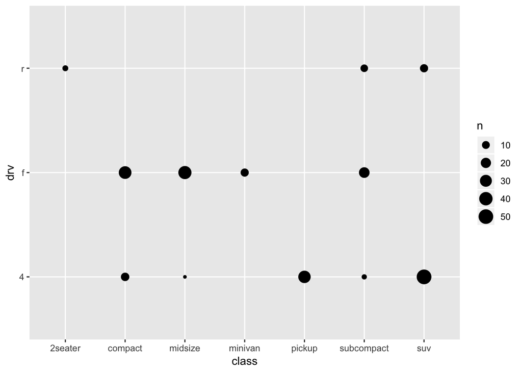

```r
ggplot(mpg, aes(x = class, y = drv)) +
  geom_count()
```

Here is the correct code:

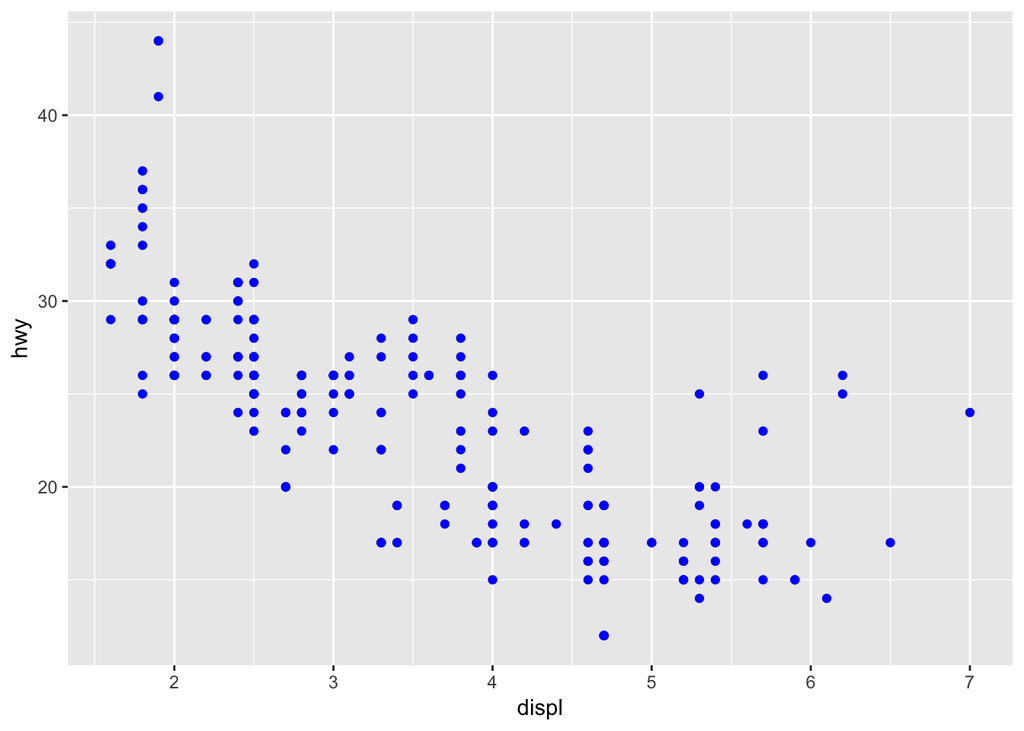

```r
ggplot(data = mpg) +
  geom_point(mapping = aes(x = displ, y = hwy), color = "blue")
```

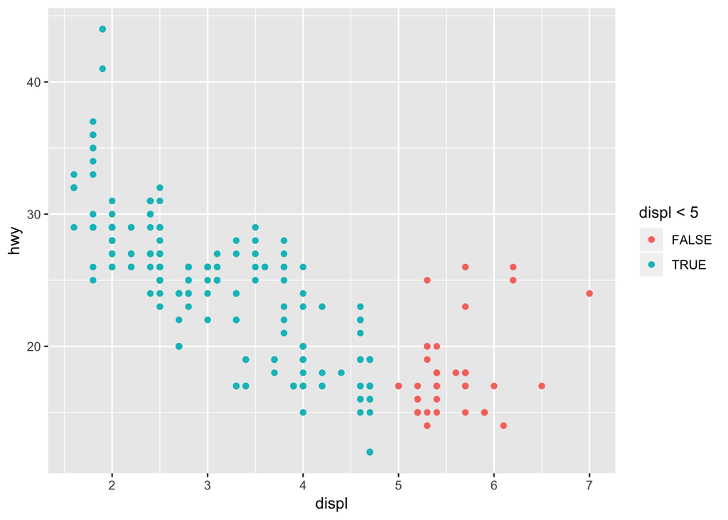

```r
ggplot(mpg, aes(x = displ, y = hwy, colour = displ < 5)) +
  geom_point()
```

### Part II

#### 1

Make a basic scatterplot of GDP per capita and life expectancy

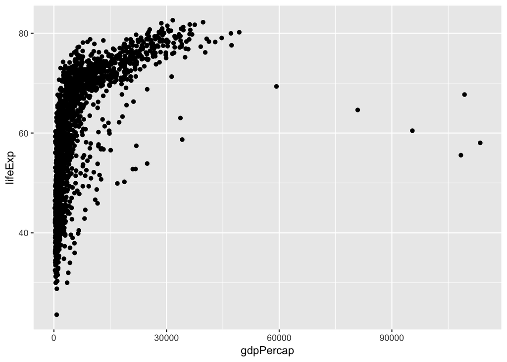

```r
ggplot(gapminder, aes(x = gdpPercap, y = lifeExp)) + geom_point()
```

#### 2

Change the graph from a scatterplot to a line using a smoother

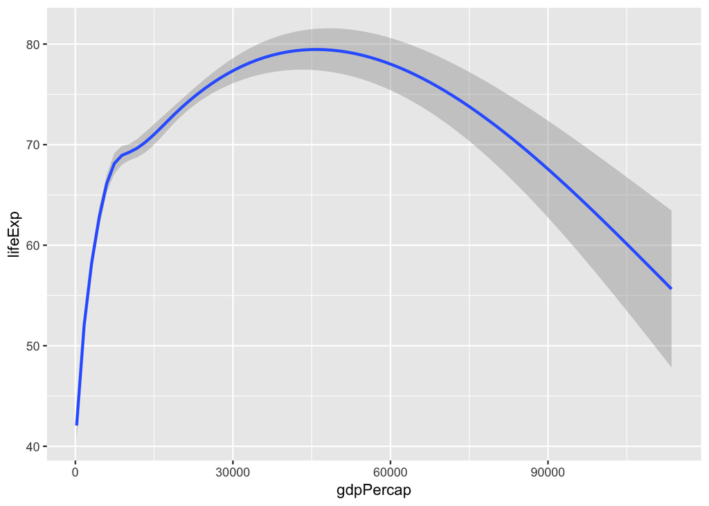

```r
ggplot(data = gapminder, mapping = aes(x = gdpPercap, y=lifeExp)) + geom_smooth()
```

#### 3

Now change the x axis to a log scale

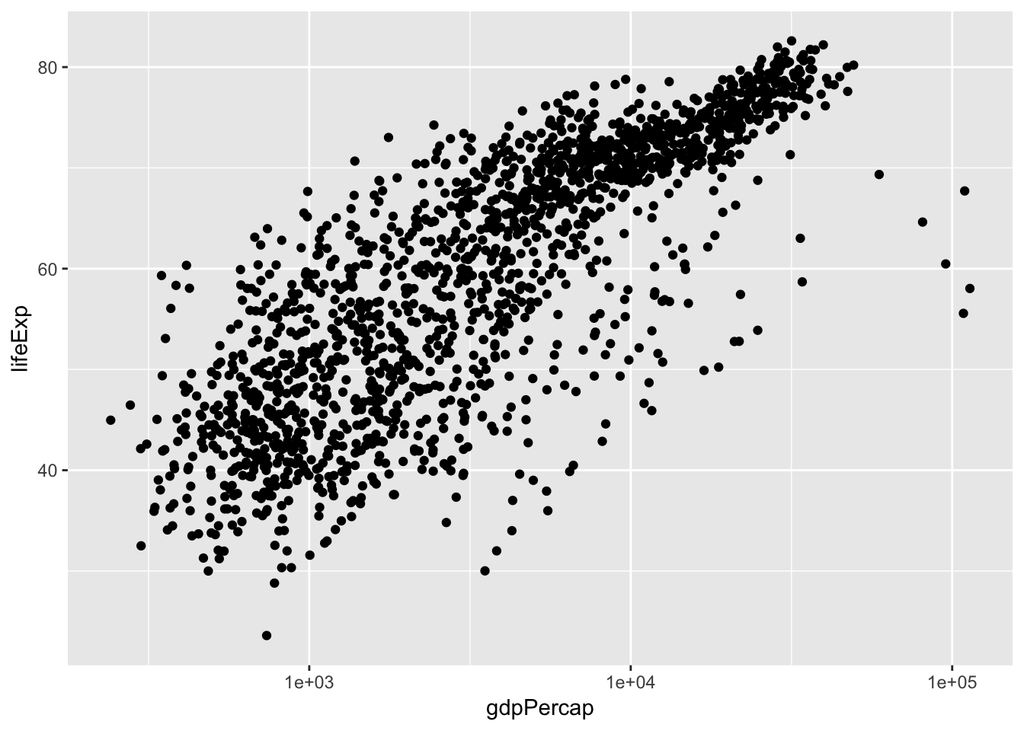

```r
ggplot(gapminder, aes(x=gdpPercap, y=lifeExp)) +
  geom_point() +
  scale_x_log10()
```

#### 4

Using only data from 1957, plot GDP per capita and life expectancy in a scatterplot. Color points according to continent and scale the x axis with a log 10 transform.

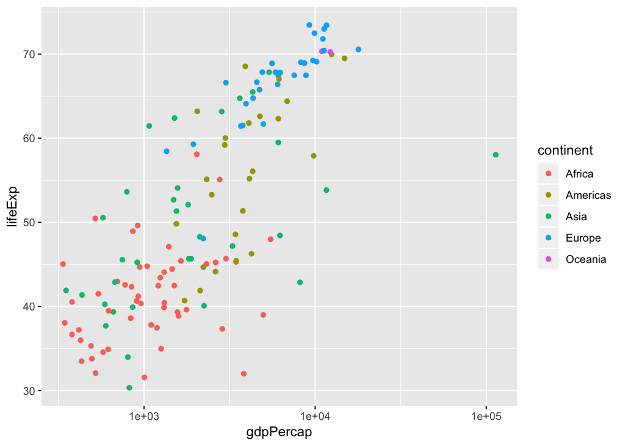

```r
ggplot(filter(gapminder, year==1957), aes(x=gdpPercap, y=lifeExp)) +
    geom_point() +
    scale_x_log10() +
    aes(color = continent)
```

Challenge:

Try out the size and shape aesthetics in a scatterplot of lifeExp vs gdpPercap.

Make the points’ size correspond to the population.

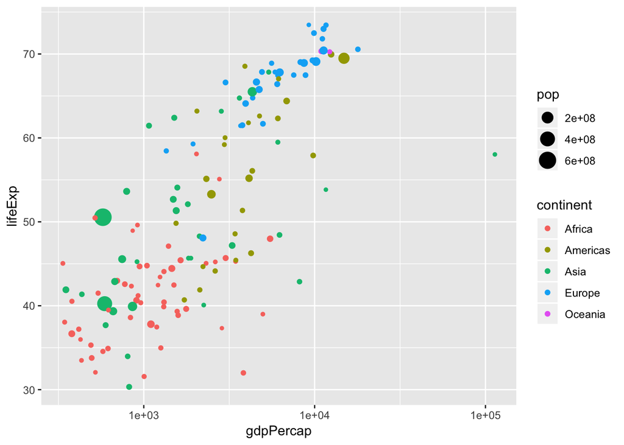

```r
ggplot(filter(gapminder, year==1957), aes(x=gdpPercap, y=lifeExp)) +
    geom_point() +
    scale_x_log10() +
    aes(color = continent, size=pop)
```

Make the points’ shape correspond to the continent

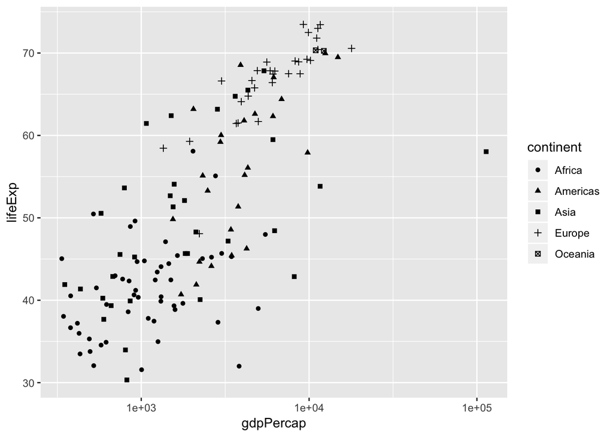

```r
ggplot(filter(gapminder, year==1957), aes(x=gdpPercap, y=lifeExp)) +
    geom_point() +
    scale_x_log10() +
    aes(shape = continent)
```

What happens if you use aes(color=pop)?

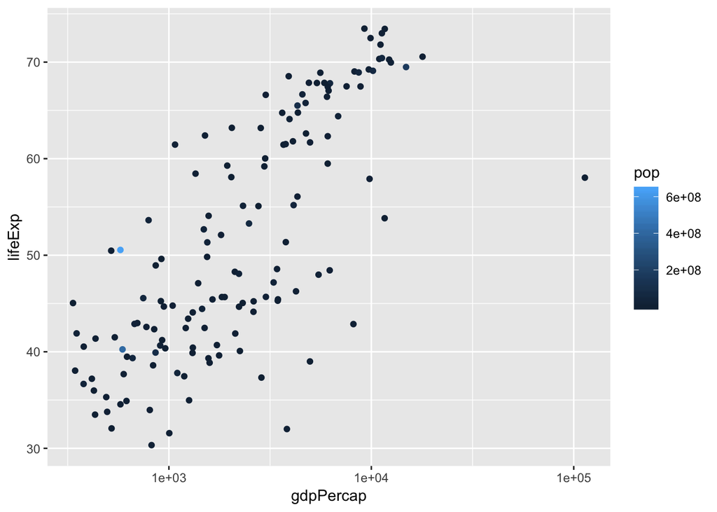

```r
ggplot(filter(gapminder, year==1957), aes(x=gdpPercap, y=lifeExp)) +
    geom_point() +
    scale_x_log10() +
    aes(color = pop)
```

#### 5

Create a histogram of life expectancy for 2007

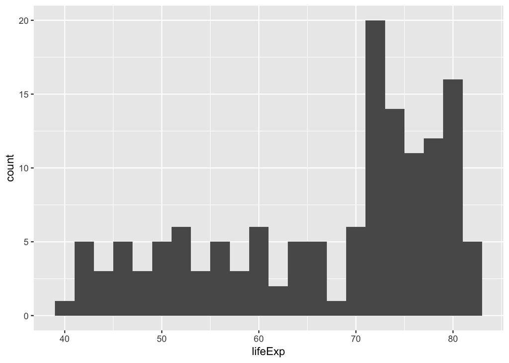

```r
gm_2007 <- filter(gapminder, year==2007)

ggplot(gm_2007, aes(x=lifeExp)) + geom_histogram(binwidth=2)
```

#### 6

compare the distributions for the different continents using density estimates

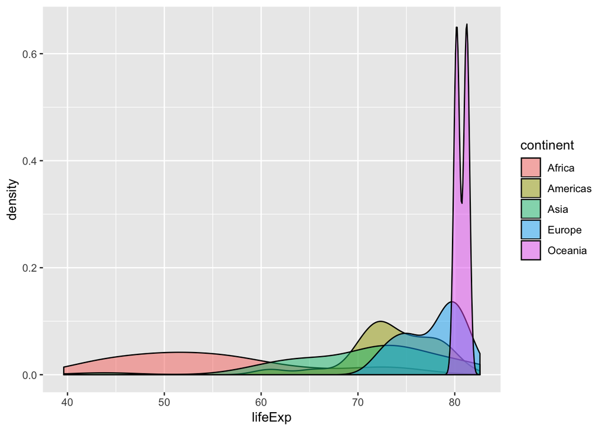

```r
ggplot(gm_2007, aes(x=lifeExp)) + geom_density(alpha=0.5) + aes(fill=continent)
```

#### 7

Express the same information in a boxplot

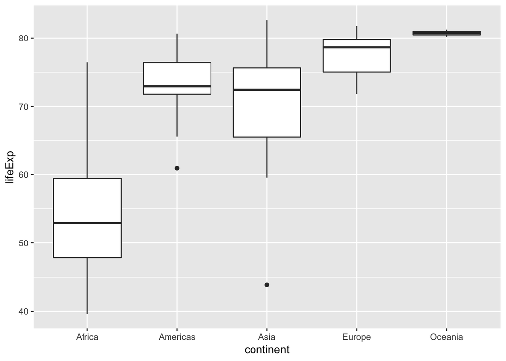

```r
ggplot(gm_2007, aes(y=lifeExp, x=continent)) + geom_boxplot()
```

#### 8

Using only data from 2007, plot GDP per capita and life expectancy for each continent using faceting. Scale the x axes by log10

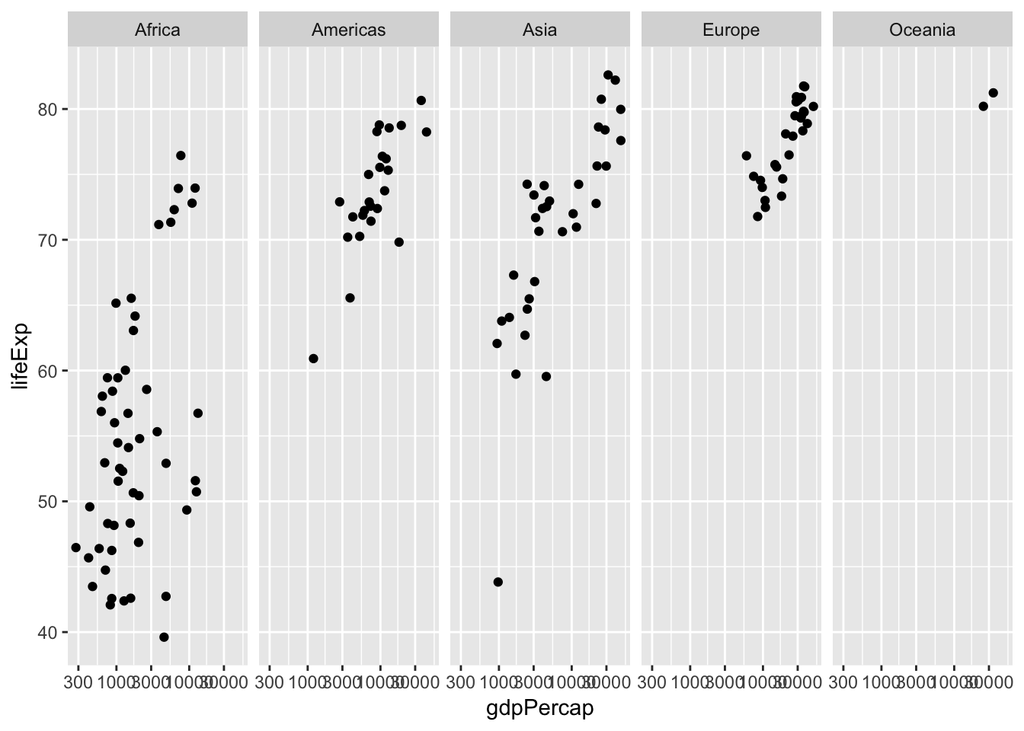

```r
p <- ggplot(filter(gapminder, year==2007), aes(x=gdpPercap, y=lifeExp)) +
  geom_point() +
  scale_x_log10()

p + facet_grid(~ continent)
```

How could you facet horizontally?

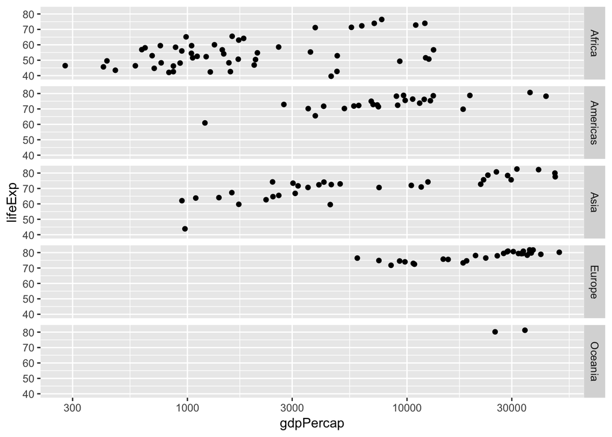

```r
p + facet_grid(continent ~ .)
```

Try using `facet_wrap`

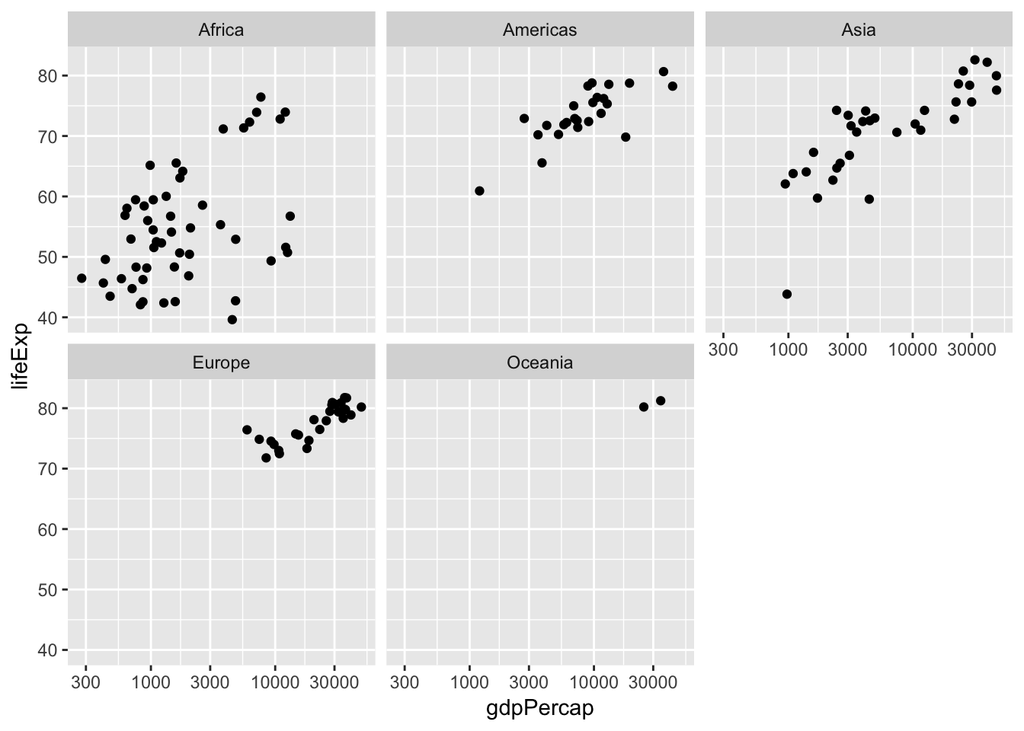

```r
p + facet_wrap(~ continent)
```

Now `facet_wrap` by year, coloring each continent differently

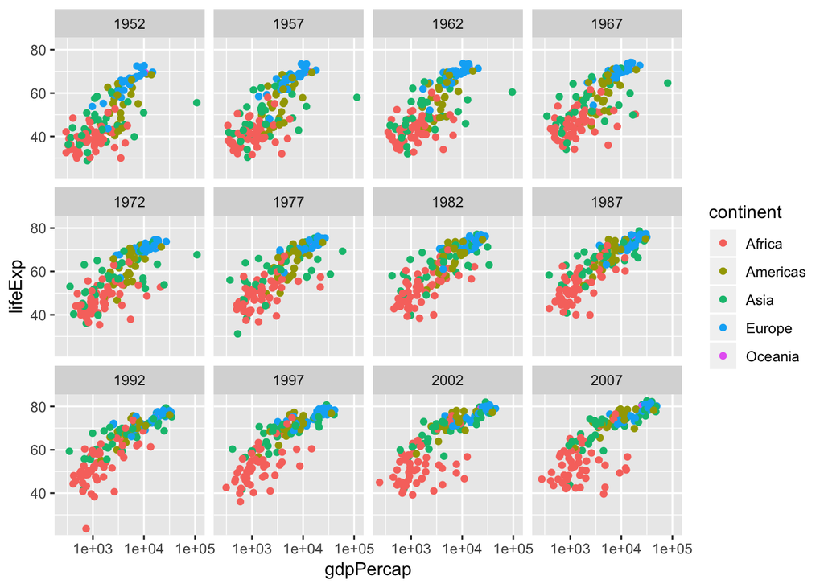

```r
p <- ggplot(gapminder, aes(x=gdpPercap, y=lifeExp)) +
  geom_point() +
  scale_x_log10()

p + aes(color=continent) + facet_wrap(~ year)
```

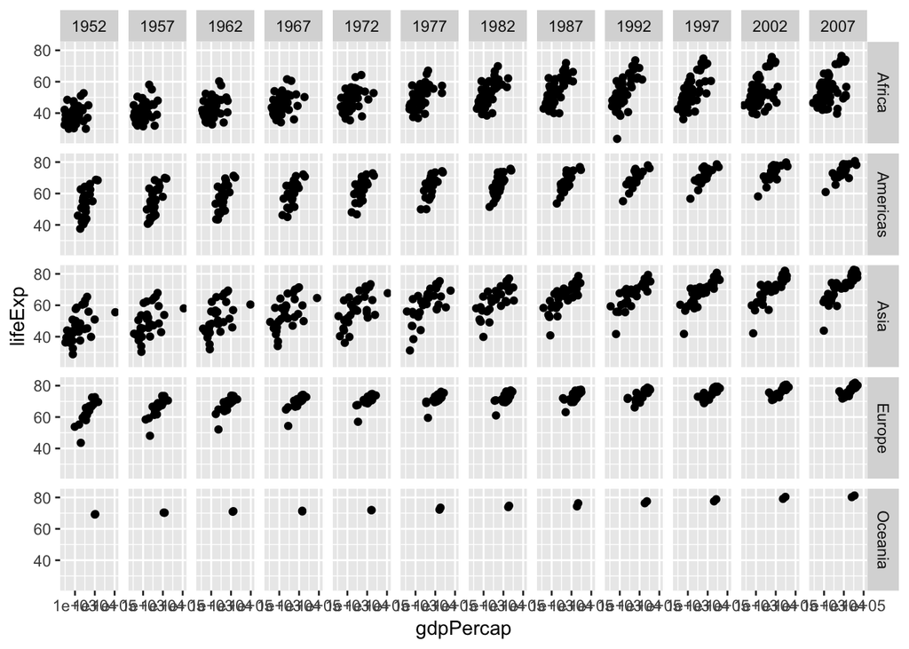

```r
p + facet_grid(continent ~ year)
```

Do your own exploratory data analysis with the `diamonds` ,`iris`, or `mtcars` datasets. Think about what type of plot you want to create before you start coding.